# pyMBE and molecular force fields

The Python-based Molecule Builder for ESPResSo (pyMBE) can interface with all-atom and CG force fields and automate the setup of force field parameters in ESPResSo.

This tutorial will focus on the AMBER99-SB and Martini 2.2 force fields.

Select mode:

- `"aa"` for all-atom model
- `"cg"` for coarse-grained model

```python
mode = "aa"
```

Install dependencies and patch ParmEd:

```
pip install vermouth insane ParmEd ipympl
sed -i "s/raise ParameterError('Not all angle parameters found/pass #raise ParameterError('Not all angle parameters found/" $(python3 -c "import parmed;print(parmed.__file__.rsplit('/', 1)[0] + '/gromacs/gromacstop.py')")
```

## Introduction

Import pyMBE library and other important libraries for this tutorial, such as ESPResSo and ParmEd.

```python
import os
import warnings
import pyMBE
import espressomd
import numpy as np
import matplotlib.pyplot as plt
import parmed.gromacs
parmed.gromacs.GROMACS_TOPDIR = os.path.join(os.environ["GMXDATA"], "top")
plt.rcParams["savefig.format"] = "svg"
```

Download and prepare peptide:

```python
if not os.path.isfile("7ETN.pdb"):
    !wget https://files.rcsb.org/download/7ETN.pdb
if not os.path.isfile("martini_v2.2.itp"):
    !wget https://cgmartini-library.s3.ca-central-1.amazonaws.com/1_Downloads/ff_parameters/martini2/particle-definitions/martini_v2.2.itp
if not os.path.isfile("martini_v2.2_aminoacids.itp"):
    !wget https://cgmartini-library.s3.ca-central-1.amazonaws.com/1_Downloads/ff_parameters/martini2/aminoacids/martini_v2.2_aminoacids.itp
!rm -f topol.top
if mode == "aa":
    !rm -f peptide_aa.gro
if mode == "cg":
    !rm -f peptide_cg.gro
!sed "/ HOH A/d; /BARG A/d; /BLYS A/d; /BSER A/d; / B   /d;" 7ETN.pdb > peptide.pdb
if mode == "aa":
    !gmx pdb2gmx -f peptide.pdb -o peptide_aa.gro -ignh -ff amber99sb -water tip3p
if mode == "cg":
    !martinize2 -f peptide.pdb -x peptide_cg.pdb -o topol.top -ff martini22 -ss C -noscfix
    !gmx editconf -f peptide_cg.pdb -o peptide_cg.gro
    with open("martini.itp", "w") as f:
        f.write('#include "martini_v2.2.itp"\n#include "martini_v2.2_aminoacids.itp"\n')
```

[output not shown]

[output cut: 37 more lines]

```
Writing topology

Back Off! I just backed up posre.itp to ./#posre.itp.13#

Writing coordinate file...

		--------- PLEASE NOTE ------------

You have successfully generated a topology from: peptide.pdb.

The Amber99sb force field and the tip3p water model are used.

		--------- ETON ESAELP ------------

GROMACS reminds you: "I Got a Forty Dollar Bill" (F. Zappa)
```

```python
def get_coord(atom):
    return [atom.xx, atom.xy, atom.xz]

def get_name(atom):
    if mode == "cg":
        return f"{atom.name}({atom.type})"
    if mode == "aa":
        return atom.name
```

```python
with warnings.catch_warnings(action="ignore"):
    gmx_top = parmed.gromacs.GromacsTopologyFile("topol.top")
    gmx_gro = parmed.gromacs.GromacsGroFile.parse(f"peptide_{mode}.gro")
gmx_top.positions = gmx_gro.positions
```

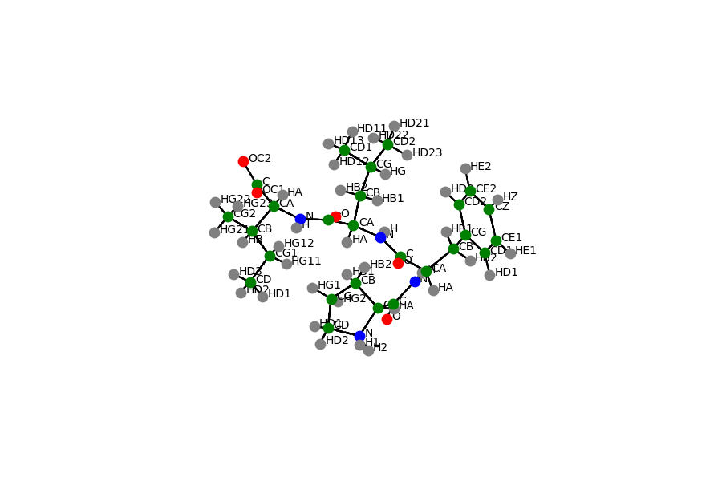

```python
from mpl_toolkits.mplot3d import Axes3D
%matplotlib widget
fig = plt.figure(figsize=(9, 6))
ax = fig.add_subplot(111, projection="3d")
for bond in gmx_top.bonds:
    ax.plot(*np.array([get_coord(bond.atom1), get_coord(bond.atom2)]).T, color="k")
for bond in gmx_top.angles:
    ax.plot(*np.array([get_coord(bond.atom1), get_coord(bond.atom2), get_coord(bond.atom3)]).T, color="k", ls="--")
for atom in gmx_top.atoms:
    ax.scatter(*get_coord(atom), marker="o", s=80, depthshade=False,
               edgecolors=None, c={1: "grey", 6: "green", 7: "blue", 8: "r"}.get(atom.atomic_number, "k"))
for atom in gmx_top.atoms:
    ax.text(*(get_coord(atom) + np.ones(3) * 0.15), get_name(atom))
ax.set_aspect("equal")
ax.set_xlabel("X axis")
ax.set_ylabel("Y axis")
ax.set_zlabel("Z axis")
ax.set_axis_off()
if mode == "aa":
    ax.view_init(elev=-10, azim=165, roll=-155, vertical_axis='z')
if mode == "cg":
    ax.view_init(elev=-12, azim=21, roll=16, vertical_axis='z')
plt.tight_layout()
```

Let us now create an instance of the ESPResSo system where we will place our molecules (a square simulation box with length = `box_l`).

```python
pmb = pyMBE.pymbe_library(seed=42)
```

When pyMBE is inicialized, a default system of reduced units is defined.

- Unit_length = 0.355 nm.
- Unit_charge = 1 elementary charge.
- Temperature = 298.15 K.

The active set of reduced units can be consulted using:

```python
print(pmb.get_reduced_units())
```

```
Current set of reduced units:
0.355 nanometer = 1 reduced_length
4.1164e-21 joule = 1 reduced_energy
1.6022e-19 coulomb = 1 reduced_charge
Temperature: 298.15 kelvin
```

```python
Box_L = 7.5*pmb.units.nm

espresso_system = espressomd.System(box_l = [Box_L.to('reduced_length').magnitude]*3)

print('The side of the simulation box is ', Box_L, '=' ,Box_L.to('reduced_length'))
```

```
The side of the simulation box is  7.5 nanometer = 21.126760563380284 reduced_length
```

## How to create simple polymers

pyMBE can be used to easily construct coarse-grained models of simple polymers. Let us consider a coarse grained model for polydehydroalanaline (PDha) (figure below) in which its monomeric unit can be represented by three beads, as depicted in the schematics below: a backbone bead (grey), a bead for the carboxylic acid group (red) and a bead for the amino group (blue).

[figure not shown]

To set up such polymer with pyMBE first one has to define the different particles in the monomer (or residue). Then, one defines the structure of the residue of the polymer. A residue is composed by a `central_bead` where one or various `side_chains` are attached. Each side chain can contain one particle or other residues.

NOTE: All input variables will be given to ESPResSo using these reduced units, since it is a convenient choice for the simulation setup. Internally, pyMBE uses Pint library to deal with unit transformations, which in turn should be used by the user to define its own variables.

```python
known_residues = set()
known_atoms = set()
for res in gmx_top.residues:
    if res.name in known_residues:
        continue
    known_residues.add(res.name)
    if mode == "cg":
        central_bead_cg = [get_name(atom) for atom in res.atoms if atom.name == "BB"][0]
    central_bead = "CA" if mode == "aa" else central_bead_cg
    pmb.define_residue(
        name=res.name,
        central_bead=central_bead,
        side_chains=[get_name(atom) for atom in res.atoms if atom.name not in ["CA", "BB"]])
    for atom in res.atoms:
        if get_name(atom) in known_atoms:
            continue
        known_atoms.add(get_name(atom))
        pmb.define_particle(name=get_name(atom),
                            z=atom.charge if mode == "cg" else int(1000*atom.charge),
                            sigma=(atom.sigma if mode == "aa" else 1.) * pmb.units('reduced_length'),
                            epsilon=(atom.epsilon if mode == "aa" else 1.) * pmb.units('reduced_energy'))
```

```python
pmb.filter_df(pmb_type='residue')
```

|  | name | pmb_type | central_bead | side_chains |
| --- | --- | --- | --- | --- |
| 0 | PRO | residue | CA | [N, H1, H2, CD, HD1, HD2, CG, HG1, HG2, CB, HB... |
| 17 | PHE | residue | CA | [N, H, HA, CB, HB1, HB2, CG, CD1, HD1, CE1, HE... |
| 27 | LEU | residue | CA | [N, H, HA, CB, HB1, HB2, CG, HG, CD1, HD11, HD... |
| 35 | ILE | residue | CA | [N, H, HA, CB, HB, CG2, HG21, HG22, HG23, CG1,... |

```python
pmb.filter_df(pmb_type='particle')
```

|  | name | pmb_type | sigma | cutoff | offset | epsilon | state_one label | state_one es_type | state_one z |
| --- | --- | --- | --- | --- | --- | --- | --- | --- | --- |
| 1 | N | particle | 3.25 reduced_length | 1.122462048309373 reduced_length | 0 reduced_length | 0.16999999999999998 reduced_energy | N | 0 | -202 |
| 2 | H1 | particle | 1.06908 reduced_length | 1.122462048309373 reduced_length | 0 reduced_length | 0.015700000000000002 reduced_energy | H1 | 1 | 312 |
| 3 | H2 | particle | 1.06908 reduced_length | 1.122462048309373 reduced_length | 0 reduced_length | 0.015700000000000002 reduced_energy | H2 | 2 | 312 |
| 4 | CD | particle | 3.3996700000000004 reduced_length | 1.122462048309373 reduced_length | 0 reduced_length | 0.10940009560229445 reduced_energy | CD | 3 | -12 |
| 5 | HD1 | particle | 1.95998 reduced_length | 1.122462048309373 reduced_length | 0 reduced_length | 0.015700000000000002 reduced_energy | HD1 | 4 | 100 |
| 6 | HD2 | particle | 1.95998 reduced_length | 1.122462048309373 reduced_length | 0 reduced_length | 0.015700000000000002 reduced_energy | HD2 | 5 | 100 |
| 7 | CG | particle | 3.3996700000000004 reduced_length | 1.122462048309373 reduced_length | 0 reduced_length | 0.10940009560229445 reduced_energy | CG | 6 | -121 |
| 8 | HG1 | particle | 2.6495299999999995 reduced_length | 1.122462048309373 reduced_length | 0 reduced_length | 0.015700000000000002 reduced_energy | HG1 | 7 | 100 |
| 9 | HG2 | particle | 2.6495299999999995 reduced_length | 1.122462048309373 reduced_length | 0 reduced_length | 0.015700000000000002 reduced_energy | HG2 | 8 | 100 |
| 10 | CB | particle | 3.3996700000000004 reduced_length | 1.122462048309373 reduced_length | 0 reduced_length | 0.10940009560229445 reduced_energy | CB | 9 | -115 |
| 11 | HB1 | particle | 2.6495299999999995 reduced_length | 1.122462048309373 reduced_length | 0 reduced_length | 0.015700000000000002 reduced_energy | HB1 | 10 | 100 |
| 12 | HB2 | particle | 2.6495299999999995 reduced_length | 1.122462048309373 reduced_length | 0 reduced_length | 0.015700000000000002 reduced_energy | HB2 | 11 | 100 |
| 13 | CA | particle | 3.3996700000000004 reduced_length | 1.122462048309373 reduced_length | 0 reduced_length | 0.10940009560229445 reduced_energy | CA | 12 | 100 |
| 14 | HA | particle | 1.95998 reduced_length | 1.122462048309373 reduced_length | 0 reduced_length | 0.015700000000000002 reduced_energy | HA | 13 | 100 |
| 15 | C | particle | 3.3996700000000004 reduced_length | 1.122462048309373 reduced_length | 0 reduced_length | 0.086 reduced_energy | C | 14 | 526 |
| 16 | O | particle | 2.95992 reduced_length | 1.122462048309373 reduced_length | 0 reduced_length | 0.21 reduced_energy | O | 15 | -500 |
| 18 | H | particle | 1.06908 reduced_length | 1.122462048309373 reduced_length | 0 reduced_length | 0.015700000000000002 reduced_energy | H | 16 | 271 |
| 19 | CD1 | particle | 3.3996700000000004 reduced_length | 1.122462048309373 reduced_length | 0 reduced_length | 0.086 reduced_energy | CD1 | 17 | -125 |
| 20 | CE1 | particle | 3.3996700000000004 reduced_length | 1.122462048309373 reduced_length | 0 reduced_length | 0.086 reduced_energy | CE1 | 18 | -170 |
| 21 | HE1 | particle | 2.59964 reduced_length | 1.122462048309373 reduced_length | 0 reduced_length | 0.014999999999999998 reduced_energy | HE1 | 19 | 143 |
| 22 | CZ | particle | 3.3996700000000004 reduced_length | 1.122462048309373 reduced_length | 0 reduced_length | 0.086 reduced_energy | CZ | 20 | -107 |
| 23 | HZ | particle | 2.59964 reduced_length | 1.122462048309373 reduced_length | 0 reduced_length | 0.014999999999999998 reduced_energy | HZ | 21 | 129 |
| 24 | CE2 | particle | 3.3996700000000004 reduced_length | 1.122462048309373 reduced_length | 0 reduced_length | 0.086 reduced_energy | CE2 | 22 | -170 |
| 25 | HE2 | particle | 2.59964 reduced_length | 1.122462048309373 reduced_length | 0 reduced_length | 0.014999999999999998 reduced_energy | HE2 | 23 | 143 |
| 26 | CD2 | particle | 3.3996700000000004 reduced_length | 1.122462048309373 reduced_length | 0 reduced_length | 0.086 reduced_energy | CD2 | 24 | -125 |
| 28 | HG | particle | 2.6495299999999995 reduced_length | 1.122462048309373 reduced_length | 0 reduced_length | 0.015700000000000002 reduced_energy | HG | 25 | -36 |
| 29 | HD11 | particle | 2.6495299999999995 reduced_length | 1.122462048309373 reduced_length | 0 reduced_length | 0.015700000000000002 reduced_energy | HD11 | 26 | 100 |
| 30 | HD12 | particle | 2.6495299999999995 reduced_length | 1.122462048309373 reduced_length | 0 reduced_length | 0.015700000000000002 reduced_energy | HD12 | 27 | 100 |
| 31 | HD13 | particle | 2.6495299999999995 reduced_length | 1.122462048309373 reduced_length | 0 reduced_length | 0.015700000000000002 reduced_energy | HD13 | 28 | 100 |
| 32 | HD21 | particle | 2.6495299999999995 reduced_length | 1.122462048309373 reduced_length | 0 reduced_length | 0.015700000000000002 reduced_energy | HD21 | 29 | 100 |
| 33 | HD22 | particle | 2.6495299999999995 reduced_length | 1.122462048309373 reduced_length | 0 reduced_length | 0.015700000000000002 reduced_energy | HD22 | 30 | 100 |
| 34 | HD23 | particle | 2.6495299999999995 reduced_length | 1.122462048309373 reduced_length | 0 reduced_length | 0.015700000000000002 reduced_energy | HD23 | 31 | 100 |
| 36 | HB | particle | 2.6495299999999995 reduced_length | 1.122462048309373 reduced_length | 0 reduced_length | 0.015700000000000002 reduced_energy | HB | 32 | 76 |
| 37 | CG2 | particle | 3.3996700000000004 reduced_length | 1.122462048309373 reduced_length | 0 reduced_length | 0.10940009560229445 reduced_energy | CG2 | 33 | -349 |
| 38 | HG21 | particle | 2.6495299999999995 reduced_length | 1.122462048309373 reduced_length | 0 reduced_length | 0.015700000000000002 reduced_energy | HG21 | 34 | 102 |
| 39 | HG22 | particle | 2.6495299999999995 reduced_length | 1.122462048309373 reduced_length | 0 reduced_length | 0.015700000000000002 reduced_energy | HG22 | 35 | 102 |
| 40 | HG23 | particle | 2.6495299999999995 reduced_length | 1.122462048309373 reduced_length | 0 reduced_length | 0.015700000000000002 reduced_energy | HG23 | 36 | 102 |
| 41 | CG1 | particle | 3.3996700000000004 reduced_length | 1.122462048309373 reduced_length | 0 reduced_length | 0.10940009560229445 reduced_energy | CG1 | 37 | -32 |
| 42 | HG11 | particle | 2.6495299999999995 reduced_length | 1.122462048309373 reduced_length | 0 reduced_length | 0.015700000000000002 reduced_energy | HG11 | 38 | 32 |
| 43 | HG12 | particle | 2.6495299999999995 reduced_length | 1.122462048309373 reduced_length | 0 reduced_length | 0.015700000000000002 reduced_energy | HG12 | 39 | 32 |
| 44 | HD3 | particle | 2.6495299999999995 reduced_length | 1.122462048309373 reduced_length | 0 reduced_length | 0.015700000000000002 reduced_energy | HD3 | 40 | 19 |
| 45 | OC1 | particle | 2.95992 reduced_length | 1.122462048309373 reduced_length | 0 reduced_length | 0.21 reduced_energy | OC1 | 41 | -819 |
| 46 | OC2 | particle | 2.95992 reduced_length | 1.122462048309373 reduced_length | 0 reduced_length | 0.21 reduced_energy | OC2 | 42 | -819 |

```python
summary = set()
for bond in gmx_top.bonds:
    identifier = f"{get_name(bond.atom1)}, {get_name(bond.atom2)}, {bond.type.k}, {bond.type.req}"
    if identifier in summary:
        continue
    summary.add(identifier)
    pmb.define_bond(bond_type="harmonic",
                    bond_parameters={"k": bond.type.k * pmb.units('reduced_energy / reduced_length**2'),
                                     "r_0": bond.type.req * pmb.units('reduced_length')},
                    particle_pairs = [[get_name(bond.atom1), get_name(bond.atom2)]])

summary = set()
for bond in gmx_top.angles:
    if bond.type is None:
        summary.add(f"need to add bond angle {get_name(bond.atom1)}-{get_name(bond.atom2)}-{get_name(bond.atom3)} theta_0=? k=?")
    else:
        summary.add(f"need to add bond angle {get_name(bond.atom1)}-{get_name(bond.atom2)}-{get_name(bond.atom3)} theta_0={bond.type.theteq:.2f} k={bond.type.k:.2f}")
for x in set(summary):
    print(x)

pmb.add_bonds_to_espresso(espresso_system=espresso_system)
```

```
need to add bond angle CB-CG2-HG21 theta_0=109.50 k=50.00
need to add bond angle CB-CG1-HG11 theta_0=109.50 k=50.00
need to add bond angle CG-CD2-HD2 theta_0=120.00 k=50.00
need to add bond angle HB1-CB-CA theta_0=109.50 k=50.00
need to add bond angle HB-CB-CG2 theta_0=109.50 k=50.00
need to add bond angle HB-CB-CG1 theta_0=109.50 k=50.00
need to add bond angle HE1-CE1-CZ theta_0=120.00 k=50.00
need to add bond angle HD1-CD1-CE1 theta_0=120.00 k=50.00
need to add bond angle CG-CD2-CE2 theta_0=120.00 k=63.00
need to add bond angle H-N-CA theta_0=118.04 k=50.00
need to add bond angle CG-CD2-HD22 theta_0=109.50 k=50.00
need to add bond angle CD-N-CA theta_0=109.50 k=50.00
need to add bond angle CD-CG-HG1 theta_0=109.50 k=50.00
need to add bond angle H2-N-CD theta_0=109.50 k=50.00
need to add bond angle CB-CG2-HG22 theta_0=109.50 k=50.00
need to add bond angle HG1-CG-HG2 theta_0=109.50 k=35.00
need to add bond angle HG11-CG1-HG12 theta_0=109.50 k=35.00
need to add bond angle N-CD-HD2 theta_0=109.50 k=50.00
need to add bond angle CB-CG1-CD theta_0=109.50 k=40.00
need to add bond angle CA-C-O theta_0=120.40 k=80.00
need to add bond angle HG21-CG2-HG23 theta_0=109.50 k=35.00
need to add bond angle CA-CB-HB1 theta_0=109.50 k=50.00
need to add bond angle CG-CD1-CE1 theta_0=120.00 k=63.00
need to add bond angle HG22-CG2-HG23 theta_0=109.50 k=35.00
need to add bond angle OC1-C-OC2 theta_0=126.00 k=80.00
need to add bond angle CE1-CZ-CE2 theta_0=120.00 k=63.00
need to add bond angle CG-CD2-HD23 theta_0=109.50 k=50.00
need to add bond angle HA-CA-C theta_0=109.50 k=50.00
need to add bond angle CG-CD2-HD21 theta_0=109.50 k=50.00
need to add bond angle CG-CB-HB2 theta_0=109.50 k=50.00
need to add bond angle HG21-CG2-HG22 theta_0=109.50 k=35.00
need to add bond angle CD1-CE1-CZ theta_0=120.00 k=63.00
need to add bond angle N-CA-HA theta_0=109.50 k=50.00
need to add bond angle HB2-CB-CG theta_0=109.50 k=50.00
need to add bond angle CA-C-OC1 theta_0=117.00 k=70.00
need to add bond angle CA-CB-CG2 theta_0=109.50 k=40.00
need to add bond angle CZ-CE2-HE2 theta_0=120.00 k=50.00
need to add bond angle CG-CD1-HD12 theta_0=109.50 k=50.00
need to add bond angle HB1-CB-CG theta_0=109.50 k=50.00
need to add bond angle HG-CG-CD2 theta_0=109.50 k=50.00
```

[output cut: 52 more lines]

```
need to add bond angle C-N-CA theta_0=121.90 k=50.00
need to add bond angle HD2-CD-HD3 theta_0=109.50 k=35.00
need to add bond angle CG-CD1-HD1 theta_0=120.00 k=50.00
need to add bond angle HD22-CD2-HD23 theta_0=109.50 k=35.00
need to add bond angle CA-C-N theta_0=116.60 k=70.00
need to add bond angle CB-CG-HG theta_0=109.50 k=50.00
need to add bond angle HG2-CG-CB theta_0=109.50 k=50.00
need to add bond angle CG-CD1-HD11 theta_0=109.50 k=50.00
need to add bond angle CB-CG2-HG23 theta_0=109.50 k=50.00
need to add bond angle HD11-CD1-HD13 theta_0=109.50 k=35.00
need to add bond angle CG-CB-HB1 theta_0=109.50 k=50.00
need to add bond angle N-CA-CB theta_0=109.70 k=80.00
need to add bond angle CG1-CD-HD3 theta_0=109.50 k=50.00
need to add bond angle CE1-CZ-HZ theta_0=120.00 k=50.00
need to add bond angle HG11-CG1-CD theta_0=109.50 k=50.00
```

```python
pmb.filter_df(pmb_type='bond')
```

|  | name | pmb_type | bond_object | parameters_of_the_potential | l0 |
| --- | --- | --- | --- | --- | --- |
| 47 | N-H1 | bond | HarmonicBond({'r_cut': 0.0, 'k': 434.0, 'r_0':... | {'k': 434.0, 'r_cut': 0.0, 'r_0': 1.01} | 1.122462 |
| 48 | N-H2 | bond | HarmonicBond({'r_cut': 0.0, 'k': 434.0, 'r_0':... | {'k': 434.0, 'r_cut': 0.0, 'r_0': 1.01} | 1.122462 |
| 49 | N-CD | bond | HarmonicBond({'r_cut': 0.0, 'k': 367.0, 'r_0':... | {'k': 367.0, 'r_cut': 0.0, 'r_0': 1.471} | 1.471000 |
| 50 | N-CA | bond | HarmonicBond({'r_cut': 0.0, 'k': 367.0, 'r_0':... | {'k': 367.0, 'r_cut': 0.0, 'r_0': 1.471} | 1.471000 |
| 51 | CD-HD1 | bond | HarmonicBond({'r_cut': 0.0, 'k': 340.0, 'r_0':... | {'k': 340.0, 'r_cut': 0.0, 'r_0': 1.09} | 1.122462 |
| 52 | CD-HD2 | bond | HarmonicBond({'r_cut': 0.0, 'k': 340.0, 'r_0':... | {'k': 340.0, 'r_cut': 0.0, 'r_0': 1.09} | 1.122462 |
| 53 | CD-CG | bond | HarmonicBond({'r_cut': 0.0, 'k': 310.0, 'r_0':... | {'k': 310.0, 'r_cut': 0.0, 'r_0': 1.5260000000... | 1.526000 |
| 54 | CG-HG1 | bond | HarmonicBond({'r_cut': 0.0, 'k': 340.0, 'r_0':... | {'k': 340.0, 'r_cut': 0.0, 'r_0': 1.09} | 1.122462 |
| 55 | CG-HG2 | bond | HarmonicBond({'r_cut': 0.0, 'k': 340.0, 'r_0':... | {'k': 340.0, 'r_cut': 0.0, 'r_0': 1.09} | 1.122462 |
| 56 | CG-CB | bond | HarmonicBond({'r_cut': 0.0, 'k': 310.0, 'r_0':... | {'k': 310.0, 'r_cut': 0.0, 'r_0': 1.5260000000... | 1.526000 |
| 57 | CB-HB1 | bond | HarmonicBond({'r_cut': 0.0, 'k': 340.0, 'r_0':... | {'k': 340.0, 'r_cut': 0.0, 'r_0': 1.09} | 1.122462 |
| 58 | CB-HB2 | bond | HarmonicBond({'r_cut': 0.0, 'k': 340.0, 'r_0':... | {'k': 340.0, 'r_cut': 0.0, 'r_0': 1.09} | 1.122462 |
| 59 | CB-CA | bond | HarmonicBond({'r_cut': 0.0, 'k': 310.0, 'r_0':... | {'k': 310.0, 'r_cut': 0.0, 'r_0': 1.5260000000... | 1.526000 |
| 60 | CA-HA | bond | HarmonicBond({'r_cut': 0.0, 'k': 340.0, 'r_0':... | {'k': 340.0, 'r_cut': 0.0, 'r_0': 1.09} | 1.122462 |
| 61 | CA-C | bond | HarmonicBond({'r_cut': 0.0, 'k': 317.0, 'r_0':... | {'k': 317.0, 'r_cut': 0.0, 'r_0': 1.522} | 1.522000 |
| 62 | C-O | bond | HarmonicBond({'r_cut': 0.0, 'k': 570.0, 'r_0':... | {'k': 570.0, 'r_cut': 0.0, 'r_0': 1.2289999999... | 1.229000 |
| 63 | C-N | bond | HarmonicBond({'r_cut': 0.0, 'k': 490.0, 'r_0':... | {'k': 490.0, 'r_cut': 0.0, 'r_0': 1.335} | 1.335000 |
| 64 | N-H | bond | HarmonicBond({'r_cut': 0.0, 'k': 434.0, 'r_0':... | {'k': 434.0, 'r_cut': 0.0, 'r_0': 1.01} | 1.122462 |
| 65 | N-CA | bond | HarmonicBond({'r_cut': 0.0, 'k': 337.0, 'r_0':... | {'k': 337.0, 'r_cut': 0.0, 'r_0': 1.449} | 1.449000 |
| 66 | CA-CB | bond | HarmonicBond({'r_cut': 0.0, 'k': 310.0, 'r_0':... | {'k': 310.0, 'r_cut': 0.0, 'r_0': 1.5260000000... | 1.526000 |
| 67 | CB-CG | bond | HarmonicBond({'r_cut': 0.0, 'k': 317.0, 'r_0':... | {'k': 317.0, 'r_cut': 0.0, 'r_0': 1.51} | 1.510000 |
| 68 | CG-CD1 | bond | HarmonicBond({'r_cut': 0.0, 'k': 469.0, 'r_0':... | {'k': 469.0, 'r_cut': 0.0, 'r_0': 1.4000000000... | 1.400000 |
| 69 | CG-CD2 | bond | HarmonicBond({'r_cut': 0.0, 'k': 469.0, 'r_0':... | {'k': 469.0, 'r_cut': 0.0, 'r_0': 1.4000000000... | 1.400000 |
| 70 | CD1-HD1 | bond | HarmonicBond({'r_cut': 0.0, 'k': 367.0, 'r_0':... | {'k': 367.0, 'r_cut': 0.0, 'r_0': 1.08} | 1.122462 |
| 71 | CD1-CE1 | bond | HarmonicBond({'r_cut': 0.0, 'k': 469.0, 'r_0':... | {'k': 469.0, 'r_cut': 0.0, 'r_0': 1.4000000000... | 1.400000 |
| 72 | CE1-HE1 | bond | HarmonicBond({'r_cut': 0.0, 'k': 367.0, 'r_0':... | {'k': 367.0, 'r_cut': 0.0, 'r_0': 1.08} | 1.122462 |
| 73 | CE1-CZ | bond | HarmonicBond({'r_cut': 0.0, 'k': 469.0, 'r_0':... | {'k': 469.0, 'r_cut': 0.0, 'r_0': 1.4000000000... | 1.400000 |
| 74 | CZ-HZ | bond | HarmonicBond({'r_cut': 0.0, 'k': 367.0, 'r_0':... | {'k': 367.0, 'r_cut': 0.0, 'r_0': 1.08} | 1.122462 |
| 75 | CZ-CE2 | bond | HarmonicBond({'r_cut': 0.0, 'k': 469.0, 'r_0':... | {'k': 469.0, 'r_cut': 0.0, 'r_0': 1.4000000000... | 1.400000 |
| 76 | CE2-HE2 | bond | HarmonicBond({'r_cut': 0.0, 'k': 367.0, 'r_0':... | {'k': 367.0, 'r_cut': 0.0, 'r_0': 1.08} | 1.122462 |
| 77 | CE2-CD2 | bond | HarmonicBond({'r_cut': 0.0, 'k': 469.0, 'r_0':... | {'k': 469.0, 'r_cut': 0.0, 'r_0': 1.4000000000... | 1.400000 |
| 78 | CD2-HD2 | bond | HarmonicBond({'r_cut': 0.0, 'k': 367.0, 'r_0':... | {'k': 367.0, 'r_cut': 0.0, 'r_0': 1.08} | 1.122462 |
| 79 | CB-CG | bond | HarmonicBond({'r_cut': 0.0, 'k': 310.0, 'r_0':... | {'k': 310.0, 'r_cut': 0.0, 'r_0': 1.5260000000... | 1.526000 |
| 80 | CG-HG | bond | HarmonicBond({'r_cut': 0.0, 'k': 340.0, 'r_0':... | {'k': 340.0, 'r_cut': 0.0, 'r_0': 1.09} | 1.122462 |
| 81 | CG-CD1 | bond | HarmonicBond({'r_cut': 0.0, 'k': 310.0, 'r_0':... | {'k': 310.0, 'r_cut': 0.0, 'r_0': 1.5260000000... | 1.526000 |
| 82 | CG-CD2 | bond | HarmonicBond({'r_cut': 0.0, 'k': 310.0, 'r_0':... | {'k': 310.0, 'r_cut': 0.0, 'r_0': 1.5260000000... | 1.526000 |
| 83 | CD1-HD11 | bond | HarmonicBond({'r_cut': 0.0, 'k': 340.0, 'r_0':... | {'k': 340.0, 'r_cut': 0.0, 'r_0': 1.09} | 1.122462 |
| 84 | CD1-HD12 | bond | HarmonicBond({'r_cut': 0.0, 'k': 340.0, 'r_0':... | {'k': 340.0, 'r_cut': 0.0, 'r_0': 1.09} | 1.122462 |
| 85 | CD1-HD13 | bond | HarmonicBond({'r_cut': 0.0, 'k': 340.0, 'r_0':... | {'k': 340.0, 'r_cut': 0.0, 'r_0': 1.09} | 1.122462 |
| 86 | CD2-HD21 | bond | HarmonicBond({'r_cut': 0.0, 'k': 340.0, 'r_0':... | {'k': 340.0, 'r_cut': 0.0, 'r_0': 1.09} | 1.122462 |
| 87 | CD2-HD22 | bond | HarmonicBond({'r_cut': 0.0, 'k': 340.0, 'r_0':... | {'k': 340.0, 'r_cut': 0.0, 'r_0': 1.09} | 1.122462 |
| 88 | CD2-HD23 | bond | HarmonicBond({'r_cut': 0.0, 'k': 340.0, 'r_0':... | {'k': 340.0, 'r_cut': 0.0, 'r_0': 1.09} | 1.122462 |
| 89 | CB-HB | bond | HarmonicBond({'r_cut': 0.0, 'k': 340.0, 'r_0':... | {'k': 340.0, 'r_cut': 0.0, 'r_0': 1.09} | 1.122462 |
| 90 | CB-CG2 | bond | HarmonicBond({'r_cut': 0.0, 'k': 310.0, 'r_0':... | {'k': 310.0, 'r_cut': 0.0, 'r_0': 1.5260000000... | 1.526000 |
| 91 | CB-CG1 | bond | HarmonicBond({'r_cut': 0.0, 'k': 310.0, 'r_0':... | {'k': 310.0, 'r_cut': 0.0, 'r_0': 1.5260000000... | 1.526000 |
| 92 | CG2-HG21 | bond | HarmonicBond({'r_cut': 0.0, 'k': 340.0, 'r_0':... | {'k': 340.0, 'r_cut': 0.0, 'r_0': 1.09} | 1.122462 |
| 93 | CG2-HG22 | bond | HarmonicBond({'r_cut': 0.0, 'k': 340.0, 'r_0':... | {'k': 340.0, 'r_cut': 0.0, 'r_0': 1.09} | 1.122462 |
| 94 | CG2-HG23 | bond | HarmonicBond({'r_cut': 0.0, 'k': 340.0, 'r_0':... | {'k': 340.0, 'r_cut': 0.0, 'r_0': 1.09} | 1.122462 |
| 95 | CG1-HG11 | bond | HarmonicBond({'r_cut': 0.0, 'k': 340.0, 'r_0':... | {'k': 340.0, 'r_cut': 0.0, 'r_0': 1.09} | 1.122462 |
| 96 | CG1-HG12 | bond | HarmonicBond({'r_cut': 0.0, 'k': 340.0, 'r_0':... | {'k': 340.0, 'r_cut': 0.0, 'r_0': 1.09} | 1.122462 |
| 97 | CG1-CD | bond | HarmonicBond({'r_cut': 0.0, 'k': 310.0, 'r_0':... | {'k': 310.0, 'r_cut': 0.0, 'r_0': 1.5260000000... | 1.526000 |
| 98 | CD-HD3 | bond | HarmonicBond({'r_cut': 0.0, 'k': 340.0, 'r_0':... | {'k': 340.0, 'r_cut': 0.0, 'r_0': 1.09} | 1.122462 |
| 99 | C-OC1 | bond | HarmonicBond({'r_cut': 0.0, 'k': 656.000000000... | {'k': 656.0000000000001, 'r_cut': 0.0, 'r_0': ... | 1.250000 |
| 100 | C-OC2 | bond | HarmonicBond({'r_cut': 0.0, 'k': 656.000000000... | {'k': 656.0000000000001, 'r_cut': 0.0, 'r_0': ... | 1.250000 |

NOTE: Currently, only harmonic and FENE bonds are supported.